# Walks Analysis: Categorical variables

by Craig W. Slinkman

July 23, 2019

### Partition all walks by age

We define walks older than 180 days are older walks and are not used in this analysis. Walks less than or equal to 180 days old we define to be younger walks.

| Age | Frequency | Percent |
| --- | --- | --- |
| Older than 180 days | 282 | 60.9 |
| Younger than or equal 180 days | 181 | 39.1 |
| All days walks | 463 | 100.0 |

### plot walks by older and younger walks

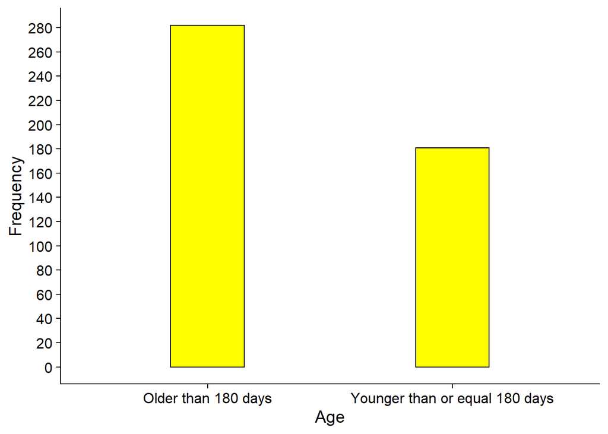

### Number of days walks mand and walks missed

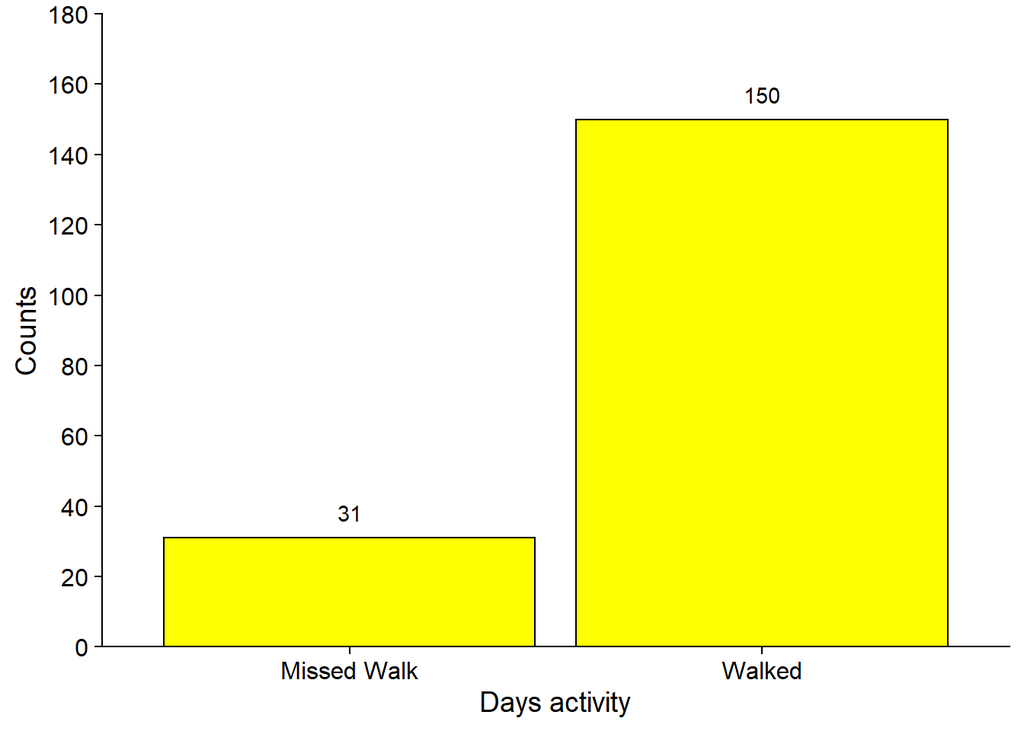

### Tabulation of reasons for missing walks

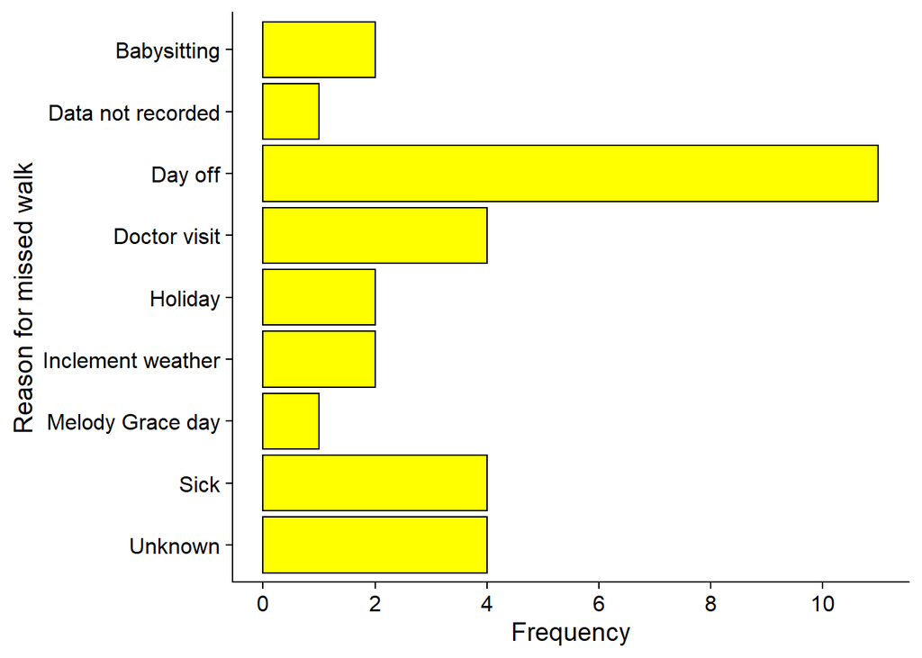

### Routes walked

This section of report gives all the routes walked during the last 180 days. Not all routes listed on this report are in use and will disappear as they age.

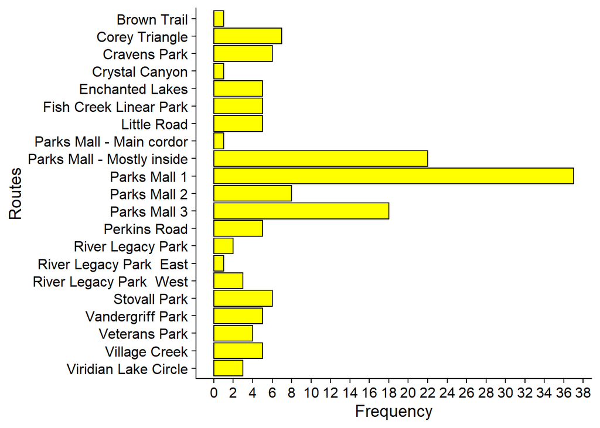

### Walks by walking environment

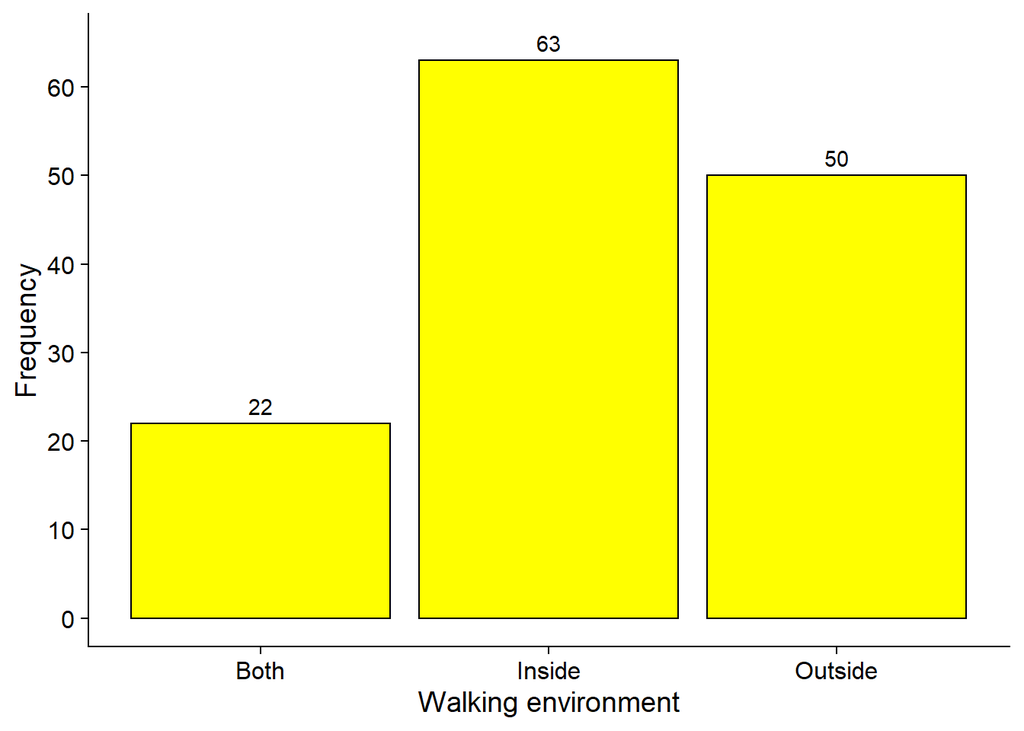

Note that the environment of both includes a walk that is mainlu inside but contains a route that is partially outside.

### Walks start times

The start hour is the hour that a walk started. Because some of my walks are inside the Parks Mall in Arlington Texas congestion can slow me down. This leads to seasonality in some of the data. The day o the walk and the start_time effect speed and any of the variables that are functions of speed.

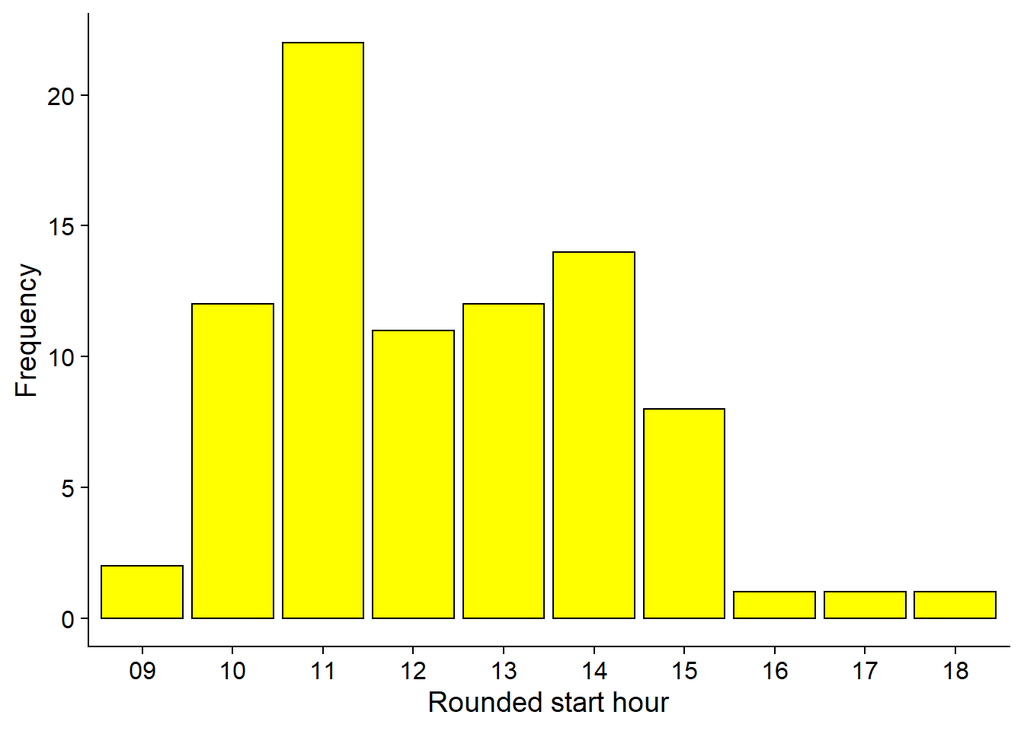